# 20211_M2.855_PEC3_Enunciado

[figure not shown]

M2.855 · Modelos avanzados de minería de datos · PAC3

2021-1 · Máster universitario en Ciencia de datos (*Data science*)

Estudios de Informática, Multimedia y Telecomunicación

# PAC 3: Métodos supervisados

En esta práctica veremos diferentes métodos supervisados y trataremos de optimizar diferentes métricas. Veremos cómo los diferentes modelos clasifican los puntos y con cuáles obtenemos mayor precisión. Después aplicaremos todo lo que hemos aprendido hasta ahora a un conjunto de datos nuevo simulando un caso práctico real.

1. Exploración de algoritmos supervisados

   ```
   1.2. K vecinos más cercanos
   1.3. Support vector machines
   1.4. Árbol de decisión
   1.5. Random forest
   1.5. Gradient boosting
   ```

2. Implementación de un caso práctico

   ```
   2.1. Análisis descriptivo
   2.2. Preprocesamiento de los datos
   2.3. Entrenamiento de un modeo
   2.4. Predicción de casos nuevos
   ```

**Importante: Cada uno de los ejercicios puede suponer varios minutos de ejecución, por lo que la entrega se ha de hacer en formato notebook y en formato html, donde se vea el código y los resultados junto con los comentarios de cada ejercicio. Para exportar el notebook a html se puede hacer desde el menú File $\to$ Download as $\to$ HTML.**

**Nombre y apellidos: Mario Ubierna San Mamés**

Para ello vamos a necesitar las siguientes librerías:

```python
from io import StringIO
from IPython.display import Image
import matplotlib as mpl
from matplotlib.colors import ListedColormap
import matplotlib.pyplot as plt
import numpy as np
import pandas as pd
import pydotplus
import seaborn as sns
from sklearn import svm
from sklearn.datasets import make_moons
from sklearn.ensemble import RandomForestClassifier, GradientBoostingClassifier, RandomForestRegressor, GradientBoostingRegressor
from sklearn.metrics import confusion_matrix, accuracy_score, mean_squared_error
from sklearn.model_selection import train_test_split, GridSearchCV
from sklearn.neighbors import KNeighborsClassifier
from sklearn.tree import DecisionTreeClassifier, DecisionTreeRegressor, export_graphviz

%matplotlib inline
```

## 1. Carga de datos

El conjunto de datos MOONS consiste en puntos en un plano que forman dos lunas, de ahí el nombre de "moons". Cada luna se corresponde a un grupo diferente [0, 1].

El siguiente código generará 1.000 puntos y hará un gráfico para visualizar las dos lunas con colores diferentes para cada grupo.

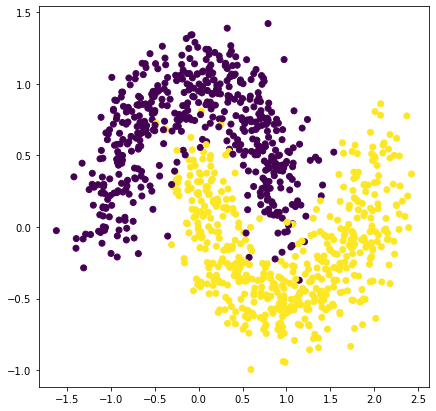

```python
df = make_moons(n_samples=1000, noise=0.2, random_state=2)
df_x = [x[0] for x in df[0]]
df_y = [x[1] for x in df[0]]
df_group = df[1]

fig, ax = plt.subplots(figsize=(7,7))
ax.scatter(df_x, df_y, c=df_group)
```

Antes de aplicar ningún modelo, hemos de separar los datos entre el conjunto de *train* y el conjunto de *test*. Siempre trabajaremos sobre el conjunto de *train* y evaluaremos los resultados en *test*.

**Implementación:** divide el *dataset* en dos subconjuntos, *train* (80% aprox.) y *test*. Puedes servirte de *train_test_split*, ya implementado en *sklearn*.

```python
X_train, X_test, y_train, y_test = train_test_split(
    df[0],
    df[1],
    test_size=0.2,
    random_state=0
)
```

A lo largo de los ejercicios veremos gráficamente las fronteras de decisión asociadas a cada uno de los diferentes modelos. Para hacerlo utilizaremos la función definida a continuación. Dicha función sigue los siguientes pasos:

- Crear una [meshgrid](https://docs.scipy.org/doc/numpy/reference/generated/numpy.meshgrid.html) con los valores mínimos y máximos de 'x' e 'y'.
- Predecir con el clasificador los valores de la *meshgrid*.
- Hacer un *reshape* de los datos para tener el formato correspondiente.

Una vez hecho esto, ya podemos crear el gráfico de las fronteras de decisión y añadirle los puntos reales. Así, veremos las áreas que el modelo considera que son de una clase y las que considera que son de otra. De esta forma, comprobaremos si el modelo clasifica los puntos correctamente dentro del área que les corresponde. También detectaremos las áreas de incertidumbre, casos en los que el modelo no se decanta ni por una clase ni por la otra (o si sí que se decanta por una pero no lo tiene 100% claro), éstas áreas serán blanquecinas.

```python
# Hacemos la meshgrid con los valores máximos y mínimos de 'x' e 'y'.
x_min, x_max = min(df_x)-0.1, max(df_x)+0.1
y_min, y_max = min(df_y)-0.1, max(df_y)+0.1

def plot_decision_boundaries(x, y, labels, model,
                             x_min=x_min,
                             x_max=x_max,
                             y_min=y_min,
                             y_max=y_max,
                             grid_step=0.02):

    xx, yy = np.meshgrid(np.arange(x_min, x_max, grid_step),
                         np.arange(y_min, y_max, grid_step))

    # Predecimos los valores de la meshgrid con el clasificador.
    Z = model.predict_proba(np.c_[xx.ravel(), yy.ravel()])[:,1]

    # Hacemos el reshape para tener el formato correcto.
    Z = Z.reshape(xx.shape)

    # Seleccionamos una paleta de color.
    arr = plt.cm.coolwarm(np.arange(plt.cm.coolwarm.N))
    arr_hsv = mpl.colors.rgb_to_hsv(arr[:,0:3])
    arr_hsv[:,2] = arr_hsv[:,2] * 1.5
    arr_hsv[:,1] = arr_hsv[:,1] * .5
    arr_hsv = np.clip(arr_hsv, 0, 1)
    arr[:,0:3] = mpl.colors.hsv_to_rgb(arr_hsv)
    my_cmap = ListedColormap(arr)

    # Creamos el gráfico con las fronteras de decisión.
    fig, ax = plt.subplots(figsize=(7,7))
    plt.pcolormesh(xx, yy, Z, cmap=my_cmap, shading='auto')

    # Añadimos los puntos.
    ax.scatter(x, y, c=labels, cmap='coolwarm')
    ax.set_xlim(xx.min(), xx.max())
    ax.set_ylim(yy.min(), yy.max())
    ax.grid(False)
```

### 1.1 $K$ vecinos más cercanos (1 punto)

El primer algoritmo que utilizaremos para clasificar los puntos es el $k$-nn. En este ejercicio, ajustaremos dos hiperparámetros del algoritmo con la intención de obtener una mayor precisión:

- $k$: el número de vecinos que se considera para clasificar un nuevo ejemplo. Probaremos con todos los valores entre 1 y 10.
- pesos: importancia que se da a cada uno de los vecinos considerados. En este caso, jugaremos con dos opciones: pesos uniformes, donde todos los vecinos se consideran de igual manera; y pesos en función de la distancia, donde los vecinos más cercanos tienen más peso en la clasificación que los vecinos más lejanos.

Para decidir cuáles son los hiperparámetros óptimos utilizaremos la técnica de búsqueda conocida como *grid search*, con la que entrenaremos un modelo para cada combinación de hiperparámetros posible y la evaluaremos utilizando validación cruzada (*cross validation*) con 4 particiones estratificadas. Posteriormente, elegiremos la combinación de hiperparámetres que mejores resultados haya obtenido.

**Implementación:** calcula el valor óptimo de los hiperparámetros *k* y *pesos*. Haz un *heatmap* para visualizar las precisiones de cada combinación según los dos hiperparámetros. Puedes utilizar los módulos GridSearchCV y KNeighborsClassifier de sklearn.

```python
# Definimos los parámetros para GridSearchCV
parametros = {
    'n_neighbors': [k + 1 for k in range(10)],
    'weights': ['uniform', 'distance']
}

# Definimos el modelo de GridSearchCV
modelo_GridSearchCSV = GridSearchCV(
    KNeighborsClassifier(),
    param_grid=parametros,
    scoring='accuracy',
    cv=4
)

# Ajustamos el modelo
modelo_GridSearchCSV = modelo_GridSearchCSV.fit(X_train, y_train)
```

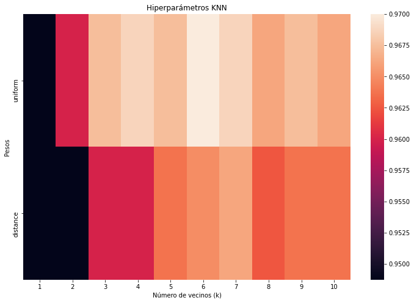

```python
# Creación del mapa de calor para cada hiperparámetro
df_GridSearchCSV = pd.DataFrame(modelo_GridSearchCSV.cv_results_["params"])
df_GridSearchCSV["accuracy"] = modelo_GridSearchCSV.cv_results_["mean_test_score"]

data = {}
for k in range(1, 11):
    data[k] = np.array(df_GridSearchCSV[df_GridSearchCSV["n_neighbors"] == k]["accuracy"])

df_heatmap = pd.DataFrame(
    data,
    columns=np.unique(df_GridSearchCSV["n_neighbors"]),
    index=reversed(np.unique(df_GridSearchCSV["weights"]))
)

fig, ax = plt.subplots(figsize=(12, 8))
sns.heatmap(df_heatmap)
plt.title("Hiperparámetros KNN")
plt.xlabel("Número de vecinos (k)")
plt.ylabel("Pesos")
plt.show()
```

```python
print("El mejor número de vecinos (k) es: ", modelo_GridSearchCSV.best_params_["n_neighbors"])
print("El mejor peso es: ", modelo_GridSearchCSV.best_params_["weights"])
print("El accuracy obtenido con los mejores hiperparámetros es: ", modelo_GridSearchCSV.best_score_)
```

```
El mejor número de vecinos (k) es:  6
El mejor peso es:  uniform
El accuracy obtenido con los mejores hiperparámetros es:  0.97
```

**Implementación:** usando los hiperparámetros con mayor precisión, representa gráficamente la frontera de decisión con el *dataset* de test y calcula su *accuracy* y su matriz de confusión.

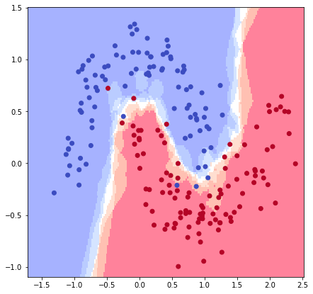

```python
# Creación del modelo con los hiperparámetros con mayor precisión
modelo_knn = KNeighborsClassifier(
    n_neighbors=modelo_GridSearchCSV.best_params_["n_neighbors"],
    weights=modelo_GridSearchCSV.best_params_["weights"]
)

# Ajustamos el modelo
modelo_knn = modelo_knn.fit(X_train, y_train)

# Representación de la frontera de decisión
plot_decision_boundaries(
    X_test[:,0],
    X_test[:,1],
    y_test,
    modelo_knn
)
```

```
El accuracy del modelo es:  0.97
```

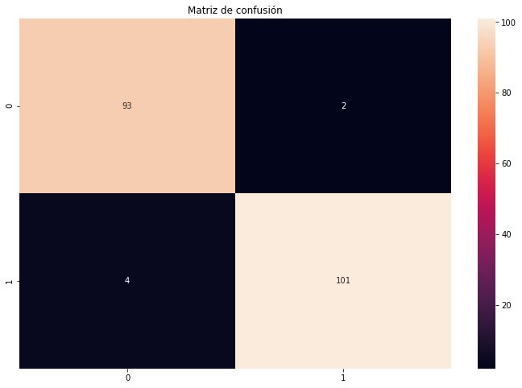

```python
# Realizamos la predicción para el conjunto de test
y_pred = modelo_knn.predict(X_test)

# Calculamos el accuracy
print("El accuracy del modelo es: ", accuracy_score(y_test, y_pred))

# Calculamos la matriz de confusión
matriz_confusion = confusion_matrix(y_test, y_pred)
fig, ax = plt.subplots(figsize=(12, 8))
sns.heatmap(matriz_confusion, annot=True, fmt='g',)
plt.title("Matriz de confusión")
plt.show()
```

**Análisis:** analiza los resultados obtenidos y en especial la frontera de descisión.

Lo primero destacar que la mejor precisión la obtenemos cuando el número de vecinos es igual a 6 y los pesos son uniformes, es decir, el número de vecinos es casi la mitad de todos los que se ha considerado (10) y cuando se da a todos los vecinos la misma importancia.

Creando el modelo con los valores indicados, luego ajustándolo con el dataset de train y prediciendo nuevas clasificaciones vemos que el modelo tiene un accuracy del 0.97, es decir, es capaz de clasificar de forma correcta el 97% de los datos nuevos. Observando la matriz de confusión, vemos que cuando la clase predicha es 0 y realmente es 1 tenemos 2 observaciones mal clasificadas, por contra, cuando la clase predicha es 1 pero realmente es 0 tenemos 4 observaciones mal clasificadas, es decir, en la gran mayoría de casos nuestro modelo se comporta de forma idónea.

Por lo que respecta a la frontera de decisión, vemos que una vez creado el modelo con los parámetros idóneos y ajustado con el conjunto de train, crea una frontera de decisión buena pero no bien definida, es decir, es capaz de generar dos áreas que permita diferenciar ambos semicírculos que hay en el problema. Visualizando los puntos del conjunto test, vemos que el modelo generado no es del todo preciso, ya que hay 2 puntos mal clasificaos (uno debería pertener a un conjunto y realmente es al otro y vicerversa), también hay unos pocos puntos que están en la zona fronteriaza, pero el modelo sí que es capaz de clasificarlos de forma general.

En resumen, el modelo se comporta de forma idónea para nuevos datos, es decir, se consigue clasificar nuevas observaciones sin cometer un gran error.

### 1.2. Support Vector Machines (1 punto)

En este segundo ejercicio, clasificaremos los puntos utilizando el algoritmo SVM con el *kernel* radial. Volveremos a utilizar *grid search*. En este caso los hiperparámetros a optimizar son:

- C: regularización, es decir, el valor de penalización de los errores en la clasificación. Indica el compromiso entre obtener el hiperplano con el margen más grande posible y clasificar el máximo número de ejemplos correctamente. Probaremos los valores: 0.01, 0.1, 1, 10, 50, 100 y 200.
- gamma: coeficiente que multiplica la distancia entre dos puntos al kernel radial. A "grosso modo", cuanto más pequeña es gamma, más influencia tienen los puntos cercanos. Probaremo los valores: 0.001, 0.01, 0.1, 1 y 10.

Igual que en el caso anterior, para validar el rendimiento del algoritmo con cada combinación de hiperparámetros utilizaremos validación cruzada (*cross-validation*) con 4 particiones estratificadas.

**Implementación:** calcula el valor óptimo de los hiperparámetros *C* y *gamma*. Haz un *heatmap* para visualizar las precisiones de cada combinación según los dos hiperparámetros. Puedes utilizar los módulos GridSearchCV y SVC de sklearn.

```python
# Definimos los parámetros para GridSearchCV
parametros = {
    'C': [0.01, 0.1, 1, 10, 50, 100, 200],
    'gamma': [0.001, 0.01, 0.1, 1, 10]
}

# Definimos el modelo de GridSearchCV
modelo_GridSearchCSV = GridSearchCV(
    svm.SVC(kernel="rbf", random_state=0),
    param_grid=parametros,
    scoring='accuracy',
    cv=4
)

# Ajustamos el modelo
modelo_GridSearchCSV = modelo_GridSearchCSV.fit(X_train, y_train)
```

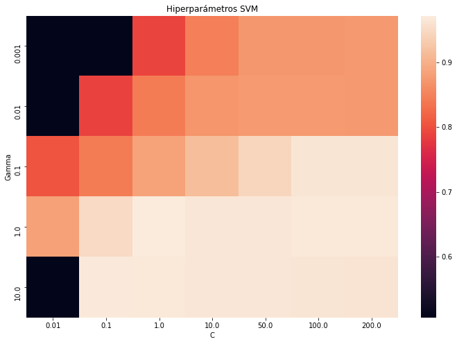

```python
# Creación del mapa de calor para cada hiperparámetro
df_GridSearchCSV = pd.DataFrame(modelo_GridSearchCSV.cv_results_["params"])
df_GridSearchCSV["accuracy"] = modelo_GridSearchCSV.cv_results_["mean_test_score"]

data = {}
for c in np.unique(df_GridSearchCSV["C"]):
    data[c] = np.array(df_GridSearchCSV[df_GridSearchCSV["C"] == c]["accuracy"])

df_heatmap = pd.DataFrame(
    data,
    columns=np.unique(df_GridSearchCSV["C"]),
    index=np.unique(df_GridSearchCSV["gamma"])
)

fig, ax = plt.subplots(figsize=(12, 8))
sns.heatmap(df_heatmap)
plt.title("Hiperparámetros SVM")
plt.xlabel("C")
plt.ylabel("Gamma")
plt.show()
```

```python
print("La mejor C es: ", modelo_GridSearchCSV.best_params_["C"])
print("La mejor gamma es: ", modelo_GridSearchCSV.best_params_["gamma"])
print("El accuracy obtenido con los mejores hiperparámetros es: ", modelo_GridSearchCSV.best_score_)
```

```
La mejor C es:  1
La mejor gamma es:  1
El accuracy obtenido con los mejores hiperparámetros es:  0.97125
```

**Implementación:** usando los hiperparámetros con mayor precisión, representa gráficamente la frontera de decisión con el *dataset* de test y calcula su *accuracy* y su matriz de confusión.

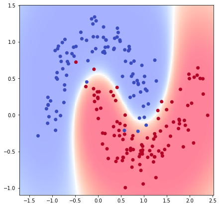

```python
# Creación del modelo con los hiperparámetros con mayor precisión
modelo_svm = svm.SVC(
    kernel="rbf",
    probability=True,
    random_state=0,
    C=modelo_GridSearchCSV.best_params_["C"],
    gamma=modelo_GridSearchCSV.best_params_["gamma"]
)

# Ajustamos el modelo
modelo_svm = modelo_svm.fit(X_train, y_train)

# Representación de la frontera de decisión
plot_decision_boundaries(
    X_test[:,0],
    X_test[:,1],
    y_test,
    modelo_svm
)
```

```
El accuracy del modelo es:  0.955
```

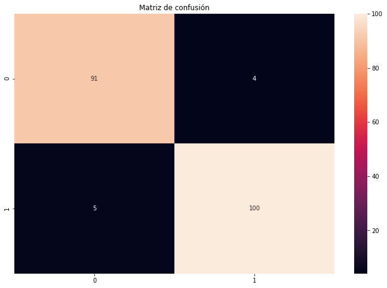

```python
# Realizamos la predicción para el conjunto de test
y_pred = modelo_svm.predict(X_test)

# Calculamos el accuracy
print("El accuracy del modelo es: ", accuracy_score(y_test, y_pred))

# Calculamos la matriz de confusión
matriz_confusion = confusion_matrix(y_test, y_pred)
fig, ax = plt.subplots(figsize=(12, 8))
sns.heatmap(matriz_confusion, annot=True, fmt='g',)
plt.title("Matriz de confusión")
plt.show()
```

**Análisis:** analiza los resultados obtenidos y en especial la frontera de descisión.

En cuanto al modelo que mejor se comporta con nuestros datos, se caracteriza porque tanto el parámetro C como gamma son iguales a 1.

Creando el modelo con esta configuración de parámetros vemos que una vez ajustado el modelo obtenemos un accuracy de 0.955, es decir, el modelo es capaz de clasificar correctamente el 95% de los datos. A la vista de la matriz de confusión vemos que clasifica de forma errónea 9 observaciones, 4 obsercaciones (cuando la clase es 0 y realmente es 1) y 5 observaciones (cuando la clase es 1 y realmente es 0).

Respecto a la frontera de decisión, vemos que está muchísimo mejor definida que en el modelo anterior, es decir, la zona fronteriza entre una área y otra es menor y encima está más ajustada, esto nos permite ver que este modelo es más preciso (calcula mejor las áreas). Sin embargo, vemos que el accuracy es algo menor para los datos que se predicen, es decir, con los datos de entrenamiento se comporta mejor este modelo, pero a la hora de predecir se comporta algo mejor el KNN.

En resumen, aunque para el conjunto de test el modelo KNN se comporta un poco mejor que el SVM, es verdad que éste último consigue hacer que la frontera de decisión sea menor, por lo que a priori a mayor número de datos mejor se va a comporta el modelo SVM respecto al KNN, aunque en nuestro caso sucede lo contrario.

### 1.3. Árboles de decisión (1 punto)

En este tercer ejercicio, clasificaremos los puntos utilizando un árbol de decisión. Utilizaremos como antes *grid search* para ajustar los hiperparámetros. En este caso ajustaremos los siguientes:

- max_depth: la profundidad máxima del árbol. Exploraremos los valores entre 4 y 10.
- min_samples_split: el mínimo número de observaciones que ha de tener una hoja del árbol para poderse dividir. Exploraremos los valores: 2, 10, 20, 50 y 100.

Igual que en los casos anteriores, utilizaremos validación cruzada (*cross-validation*) con 4 particiones estratificadas para validar el rendimiento del algoritmo con cada combinación de hiperparámetros.

**Implementación:** calcula el valor óptimo de los hiperparámetros *max_depth* y *min_samples_split*. Haz un *heatmap* para visualizar las precisiones de cada combinación según los dos hiperparámetros. Puedes utilizar los módulos GridSearchCV y DecisionTreeClassifier de sklearn.

```python
# Definimos los parámetros para GridSearchCV
parametros = {
    'max_depth': [x for x in range(4,11)],
    'min_samples_split': [2, 10, 20, 50, 100]
}

# Definimos el modelo de GridSearchCV
modelo_GridSearchCSV = GridSearchCV(
    DecisionTreeClassifier(random_state=0),
    param_grid=parametros,
    scoring='accuracy',
    cv=4
)

# Ajustamos el modelo
modelo_GridSearchCSV = modelo_GridSearchCSV.fit(X_train, y_train)
```

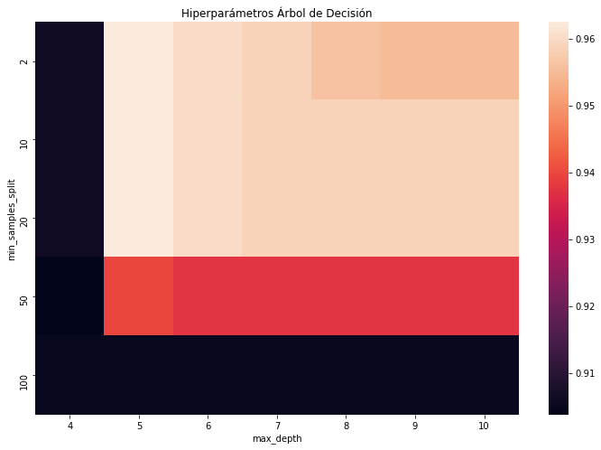

```python
# Creación del mapa de calor para cada hiperparámetro
df_GridSearchCSV = pd.DataFrame(modelo_GridSearchCSV.cv_results_["params"])
df_GridSearchCSV["accuracy"] = modelo_GridSearchCSV.cv_results_["mean_test_score"]

data = {}
for m_d in np.unique(df_GridSearchCSV["max_depth"]):
    data[m_d] = np.array(df_GridSearchCSV[df_GridSearchCSV["max_depth"] == m_d]["accuracy"])

df_heatmap = pd.DataFrame(
    data,
    columns=np.unique(df_GridSearchCSV["max_depth"]),
    index=np.unique(df_GridSearchCSV["min_samples_split"])
)

fig, ax = plt.subplots(figsize=(12, 8))
sns.heatmap(df_heatmap)
plt.title("Hiperparámetros Árbol de Decisión")
plt.xlabel("max_depth")
plt.ylabel("min_samples_split")
plt.show()
```

```python
print("El mejor max_depth es: ", modelo_GridSearchCSV.best_params_["max_depth"])
print("El mejor min_samples_split es: ", modelo_GridSearchCSV.best_params_["min_samples_split"])
print("El accuracy obtenido con los mejores hiperparámetros es: ", modelo_GridSearchCSV.best_score_)
```

```
El mejor max_depth es:  5
El mejor min_samples_split es:  2
El accuracy obtenido con los mejores hiperparámetros es:  0.9624999999999999
```

**Implementación:** usando los hiperparámetros con mayor precisión, representa gráficamente la frontera de decisión con el *dataset* de test y calcula su *accuracy* y su matriz de confusión.

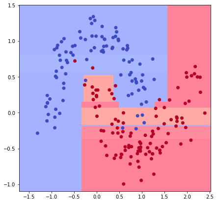

```python
# Creación del modelo con los hiperparámetros con mayor precisión
modelo_dtc = DecisionTreeClassifier(
    random_state=0,
    max_depth=modelo_GridSearchCSV.best_params_["max_depth"],
    min_samples_split=modelo_GridSearchCSV.best_params_["min_samples_split"]
)

# Ajustamos el modelo
modelo_dtc = modelo_dtc.fit(X_train, y_train)

# Representación de la frontera de decisión
plot_decision_boundaries(
    X_test[:,0],
    X_test[:,1],
    y_test,
    modelo_dtc
)
```

```
El accuracy del modelo es:  0.945
```

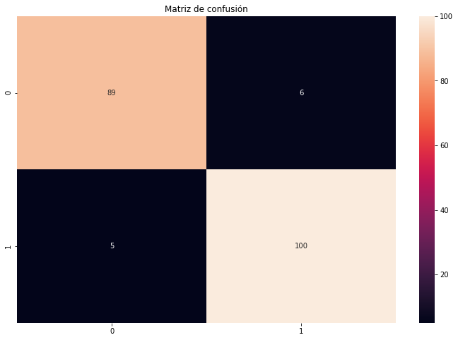

```python
# Realizamos la predicción para el conjunto de test
y_pred = modelo_dtc.predict(X_test)

# Calculamos el accuracy
print("El accuracy del modelo es: ", accuracy_score(y_test, y_pred))

# Calculamos la matriz de confusión
matriz_confusion = confusion_matrix(y_test, y_pred)
fig, ax = plt.subplots(figsize=(12, 8))
sns.heatmap(matriz_confusion, annot=True, fmt='g',)
plt.title("Matriz de confusión")
plt.show()
```

**Análisis:** analiza los resultados obtenidos y en especial la frontera de descisión.

El modelo que proporciona un mayor accuracy es con los parámetros:

- max_depth = 5
- min_samples_split = 2

Una vez creado el modelo y ajustado con los datos de entrenamiento, hemos obtenido un accuracy del 0.945, es decir, para nuevos datos el modelo es capaz de clasificar correctamente el 94.5% de las nuevas observaciones, comete 6 errores cuando la clase predicha es 0 y realmente es 1, y comete 5 errores cuando la clase predicha es 1 pero realmente es 0.

Respecto a la frontera de decisión vemos que ha cambiado completamente si la comparamos con KNN y SVM, es decir, en este caso los cortes que se realizan en el plano son ortogonales, por ejemplo en SVM al calcular un hiperplano alejado de las dos dimensiones es capaz de definir una línea fronteriza adaptada de una mejor forma a los datos, y de manera similar sucede con KNN. Aun así vemos que este modelo no se comporta mal del todo, su accuracy es 0.945, pero éste es menor que en los casos de KNN y SVM.

En resumen, en este caso vemos que ha cambiado la forma de definir la frontera de decisión, para ello se hacen cortes ortogonales en el plano. Comparando este modelo con los anteriores vemos que es un pelín peor en cuanto a la precisión del mismo para nuevos datos, pero éste no se comporta mal del todo.

### 1.4. Random forest (1 punto)

En este cuarto ejercicio, clasificaremos los puntos utilizando Random forest. Utilizaremos, como hasta ahora, *grid search* para ajustar los hiperparámetros y ajustaremos:

- max_depth: la profundidad máxima del árbol. Exploraremos los valores comprendidos entre 6 y 12.
- n_estimators: número de árboles. Exploraremos los valores: 10, 50, 100 y 200.

Igual que en los casos anteriores, utilizaremos validación cruzada (*cross-validation*) con 4 particiones estratificadas para validar el rendimiento del algoritmo con cada combinación de hiperparámetros.

**Implementación:** calcula el valor óptimo de los hiperparámetros *max_depth* y *n_estimators*. Haz un *heatmap* para visualizar las precisiones de cada combinación según los dos hiperparámetros. Puedes utilizar los módulos GridSearchCV y RandomForestClassifier de sklearn.

```python
# Definimos los parámetros para GridSearchCV
parametros = {
    'max_depth': [x for x in range(6,13)],
    'n_estimators': [10, 50, 100, 200]
}

# Definimos el modelo de GridSearchCV
modelo_GridSearchCSV = GridSearchCV(
    RandomForestClassifier(random_state=0),
    param_grid=parametros,
    scoring='accuracy',
    cv=4
)

# Ajustamos el modelo
modelo_GridSearchCSV = modelo_GridSearchCSV.fit(X_train, y_train)
```

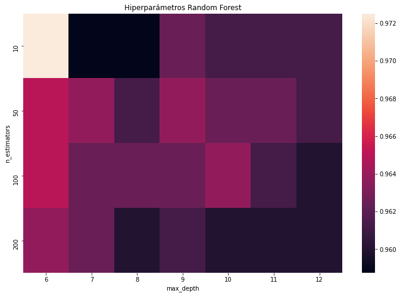

```python
# Creación del mapa de calor para cada hiperparámetro
df_GridSearchCSV = pd.DataFrame(modelo_GridSearchCSV.cv_results_["params"])
df_GridSearchCSV["accuracy"] = modelo_GridSearchCSV.cv_results_["mean_test_score"]

data = {}
for m_d in np.unique(df_GridSearchCSV["max_depth"]):
    data[m_d] = np.array(df_GridSearchCSV[df_GridSearchCSV["max_depth"] == m_d]["accuracy"])

df_heatmap = pd.DataFrame(
    data,
    columns=np.unique(df_GridSearchCSV["max_depth"]),
    index=np.unique(df_GridSearchCSV["n_estimators"])
)

fig, ax = plt.subplots(figsize=(12, 8))
sns.heatmap(df_heatmap)
plt.title("Hiperparámetros Random Forest")
plt.xlabel("max_depth")
plt.ylabel("n_estimators")
plt.show()
```

```python
print("El mejor max_depth es: ", modelo_GridSearchCSV.best_params_["max_depth"])
print("El mejor n_estimators es: ", modelo_GridSearchCSV.best_params_["n_estimators"])
print("El accuracy obtenido con los mejores hiperparámetros es: ", modelo_GridSearchCSV.best_score_)
```

```
El mejor max_depth es:  6
El mejor n_estimators es:  10
El accuracy obtenido con los mejores hiperparámetros es:  0.9724999999999999
```

**Implementación:** usando los hiperparámetros con mayor precisión, representa gráficamente la frontera de decisión con el *dataset* de test y calcula su *accuracy* y su matriz de confusión.

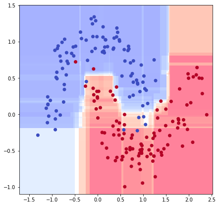

```python
# Creación del modelo con los hiperparámetros con mayor precisión
modelo_rfc = RandomForestClassifier(
    random_state=0,
    max_depth=modelo_GridSearchCSV.best_params_["max_depth"],
    n_estimators=modelo_GridSearchCSV.best_params_["n_estimators"]
)

# Ajustamos el modelo
modelo_rfc = modelo_rfc.fit(X_train, y_train)

# Representación de la frontera de decisión
plot_decision_boundaries(
    X_test[:,0],
    X_test[:,1],
    y_test,
    modelo_rfc
)
```

```
El accuracy del modelo es:  0.945
```

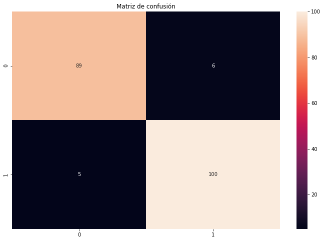

```python
# Realizamos la predicción para el conjunto de test
y_pred = modelo_rfc.predict(X_test)

# Calculamos el accuracy
print("El accuracy del modelo es: ", accuracy_score(y_test, y_pred))

# Calculamos la matriz de confusión
matriz_confusion = confusion_matrix(y_test, y_pred)
fig, ax = plt.subplots(figsize=(12, 8))
sns.heatmap(matriz_confusion, annot=True, fmt='g',)
plt.title("Matriz de confusión")
plt.show()
```

**Análisis:** analiza los resultados obtenidos y en especial la frontera de descisión.

En cuanto al modelo que mejor se ajusta a los datos de entrenamiento es con los siguientes parámetros:

- max_depth = 6
- n_estimators = 10

Con este modelo se consigue un accuracy del 0.945, es decir, consigue clasificar de forma correcta el 94.5% de las observaciones nuevas, comiento dos errores:

- Clasifica de forma incorrecta 6 observaciones predichas como clase 0 cuando realmente son 1.
- Clasifica también de forma incorrecta 5 observaciones como clase 1 cuando son clase 0.

A la vista de la frontera de decisión, vemos que ha mejorado respecto al modelo anterior, es decir, al árbol de decisión, sin embargo, esta mejora es insuficiente respecto a los modelos KNN y SVM ya que a la hora de clasificar nuevos datos su accuracy es algo más bajo, aun así es un buen modelo. Esta diferencia respecto a KNN y SVM se debe a que se siguen haciendo cortes ortogonales, y en cuanto al árbol de decisión, al generar 10 árboles en vez de 1 el modelo de random forest consigue generalizar mejor y ajustar la frontera de decisión.

En resumen, el modelo de random forest se comporta un poco mejor que el árbol de decisión, pero esta mejora es insuficiente respecto a KNN y SVM.

### 1.5. Gradient boosting (1 punto)

En este ejercicio clasificaremos los puntos utilizando Gradient boosting. Emplearemos como hasta ahora *grid search* para ajustar los siguientes hiperparámetros:

- learning_rate: velocidad de aprendizaje. Si su valor es muy alto, correremos el riesgo de no encontrar el valor óptimo por más que el algoritmo busque; mientras que si el valor es muy bajo, éste puede tardar mucho en converger y estancarse en un mínimo local. Exploraremos los valores: 0.01, 0.1, 1 y 2.
- n_estimators: número de árboles. Exploraremos los valores: 10, 50, 100 y 200.

Igual que en los casos anteriores, utilizaremos validación cruzada (*cross-validation*) con 4 particiones estratificadas para validar el rendimiento del algoritmo con cada combinación de hiperparámetros.

**Implementación:** calcula el valor óptimo de los hiperparámetros *learning_rate* y *n_estimators*. Haz un *heatmap* para visualizar las precisiones de cada combinación según los dos hiperparámetros. Puedes utilizar los módulos GridSearchCV y GradientBoostingClassifier de sklearn.

```python
# Definimos los parámetros para GridSearchCV
parametros = {
    'learning_rate': [0.01, 0.1, 1, 2],
    'n_estimators': [10, 50, 100, 200]
}

# Definimos el modelo de GridSearchCV
modelo_GridSearchCSV = GridSearchCV(
    GradientBoostingClassifier(random_state=0),
    param_grid=parametros,
    scoring='accuracy',
    cv=4
)

# Ajustamos el modelo
modelo_GridSearchCSV = modelo_GridSearchCSV.fit(X_train, y_train)
```

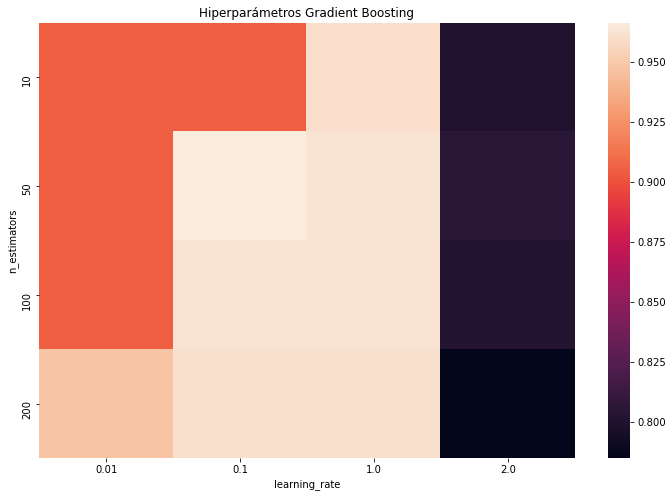

```python
# Creación del mapa de calor para cada hiperparámetro
df_GridSearchCSV = pd.DataFrame(modelo_GridSearchCSV.cv_results_["params"])
df_GridSearchCSV["accuracy"] = modelo_GridSearchCSV.cv_results_["mean_test_score"]

data = {}
for l_r in np.unique(df_GridSearchCSV["learning_rate"]):
    data[l_r] = np.array(df_GridSearchCSV[df_GridSearchCSV["learning_rate"] == l_r]["accuracy"])

df_heatmap = pd.DataFrame(
    data,
    columns=np.unique(df_GridSearchCSV["learning_rate"]),
    index=np.unique(df_GridSearchCSV["n_estimators"])
)

fig, ax = plt.subplots(figsize=(12, 8))
sns.heatmap(df_heatmap)
plt.title("Hiperparámetros Gradient Boosting")
plt.xlabel("learning_rate")
plt.ylabel("n_estimators")
plt.show()
```

```python
print("El mejor learning_rate es: ", modelo_GridSearchCSV.best_params_["learning_rate"])
print("El mejor n_estimators es: ", modelo_GridSearchCSV.best_params_["n_estimators"])
print("El accuracy obtenido con los mejores hiperparámetros es: ", modelo_GridSearchCSV.best_score_)
```

```
El mejor learning_rate es:  0.1
El mejor n_estimators es:  50
El accuracy obtenido con los mejores hiperparámetros es:  0.9662499999999999
```

**Implementación:** usando los hiperparámetros con mayor precisión, representa gráficamente la frontera de decisión con el *dataset* de test y calcula su *accuracy* y su matriz de confusión.

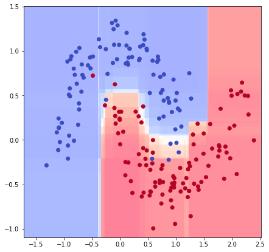

```python
# Creación del modelo con los hiperparámetros con mayor precisión
modelo_gbc = GradientBoostingClassifier(
    random_state=0,
    learning_rate=modelo_GridSearchCSV.best_params_["learning_rate"],
    n_estimators=modelo_GridSearchCSV.best_params_["n_estimators"]
)

# Ajustamos el modelo
modelo_gbc = modelo_gbc.fit(X_train, y_train)

# Representación de la frontera de decisión
plot_decision_boundaries(
    X_test[:,0],
    X_test[:,1],
    y_test,
    modelo_gbc
)
```

```
El accuracy del modelo es:  0.95
```

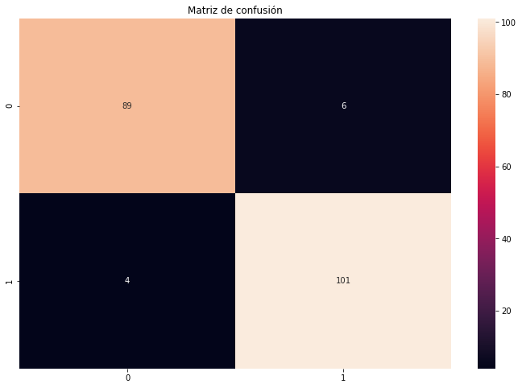

```python
# Realizamos la predicción para el conjunto de test
y_pred = modelo_gbc.predict(X_test)

# Calculamos el accuracy
print("El accuracy del modelo es: ", accuracy_score(y_test, y_pred))

# Calculamos la matriz de confusión
matriz_confusion = confusion_matrix(y_test, y_pred)
fig, ax = plt.subplots(figsize=(12, 8))
sns.heatmap(matriz_confusion, annot=True, fmt='g',)
plt.title("Matriz de confusión")
plt.show()
```

**Análisis:** analiza los resultados obtenidos y en especial la frontera de descisión.

Respecto al mejor modelo para este problema, se caracteriza por tener los siguientes valores:

- learning_rate = 0.1.
- n_estimatros = 50.

Creando el modelo con estos parámetros y ajustando con los datos de entrenamiento, se obtiene un accuracy de 0.95, es decir, se consigue clasificar de forma correcta el 95% de los nuevos datos. Aun así se cometen dos errores:

- Hay 6 observaciones que se clasifican como 0 cuando realmente tendría que ser 1.
- Hay 4 obesrvaciones que sucede lo contrario.

En cuanto a la frontera de decisión, vemos que ésta sí que ha mejorado respecto al árbol de decisión y del random forest, ya que está más definida permitiendo así que la precisión del modelo sea mejor. Sin embargo, sigue sin ser mejor que los modelos KNN y SVM, principalmente porque las áreas que detecta no se ajustan del todo a los datos, provocando un mayor error en la clasificación de nuevas observaciones.

En resumen, este modelo se comporta mejor que el modelo de árbol de decisión o random forest, pero sigue sin ser mejor que KNN o SVM.

# 2. Implementación de un caso práctico (5 puntos)

Ahora que ya entendemos cómo funcionan algunos modelos, vamos a aplicarlos a un caso práctico. La primera mitad de la práctica se ha realizado utilizando una variable objetivo categórica, para esta segunda mitad emplearemos una variable objetivo numérica. Es decir, trabajaremos con un problema de regresión, no de clasificación.

Utilizaremos un conjunto de datos público de precios de viviendas en Taiwán con el objetivo de encontrar las mejores ofertas del mercado. La descripción completa del conjunto de datos la podemos encontrar en el siguiente enlace: https://archive.ics.uci.edu/ml/datasets/Real+estate+valuation+data+set

Comencemos cargando los datos en un DataFrame de pandas:

```python
dataset = pd.read_excel('./data/Real estate valuation data set.xlsx', engine='openpyxl')

dataset.head()
```

|  | No | X1 transaction date | X2 house age | X3 distance to the nearest MRT station | X4 number of convenience stores | X5 latitude | X6 longitude | Y house price of unit area |
| --- | --- | --- | --- | --- | --- | --- | --- | --- |
| 0 | 1 | 2012.916667 | 32.0 | 84.87882 | 10 | 24.98298 | 121.54024 | 37.9 |
| 1 | 2 | 2012.916667 | 19.5 | 306.59470 | 9 | 24.98034 | 121.53951 | 42.2 |
| 2 | 3 | 2013.583333 | 13.3 | 561.98450 | 5 | 24.98746 | 121.54391 | 47.3 |
| 3 | 4 | 2013.500000 | 13.3 | 561.98450 | 5 | 24.98746 | 121.54391 | 54.8 |
| 4 | 5 | 2012.833333 | 5.0 | 390.56840 | 5 | 24.97937 | 121.54245 | 43.1 |

La primera columna ("*No*") es el identificador numérico de la muestra. Las columnes "*Xn ...*" son los diferentes atributos descriptivos. Finalmente, la columna "*Y ...*" es el valor objetivo o precio de la vivienda.

Extraemos del *DataFrame* la variable objetivo y los atributos descriptivos que utilizaremos posteriormente en el modelo predictivo:

```python
X = dataset[[
    'X2 house age',
    'X3 distance to the nearest MRT station',
    'X4 number of convenience stores',
    'X5 latitude',
    'X6 longitude'
]]

y = dataset['Y house price of unit area']
```

### 2.1. Análisis descriptivo

Cuando se nos proporciona un dataset, antes de comenzar a hacer nada, es muy importante hacer un análisis exploratorio para conocer los datos con los que trabajaremos.

**Implementación:** analizar gráficamente la distribución de todas las variables (features y target). Recuerda que las variables categóricass se representan con gráficas de barras, mientras que las numéricas se representan con histogramas.

```python
def distribution_chart(df, var):
    fig, ax = plt.subplots(figsize=(10, 8))
    if var == "X4 number of convenience stores":
        sns.countplot(x=df[var], data=df, color="blue")
    else:
        sns.histplot(data=df, x=df[var], color="blue")
    plt.title(var)
    plt.show()
```

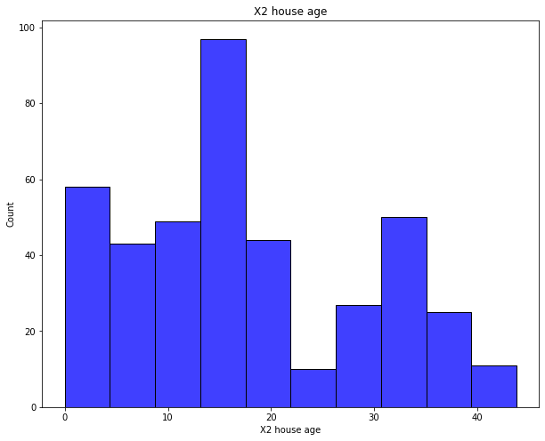

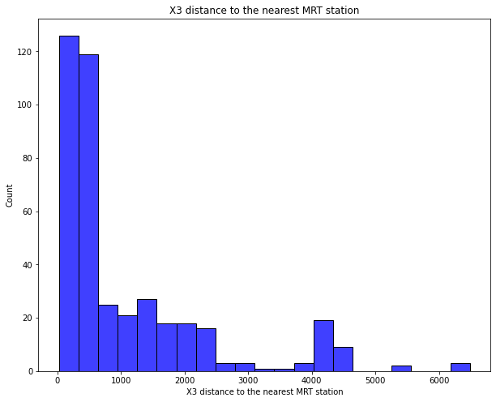

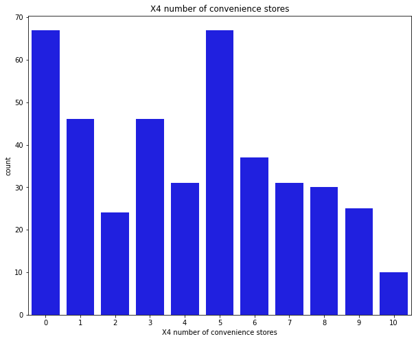

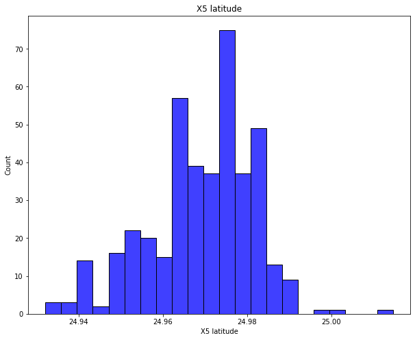

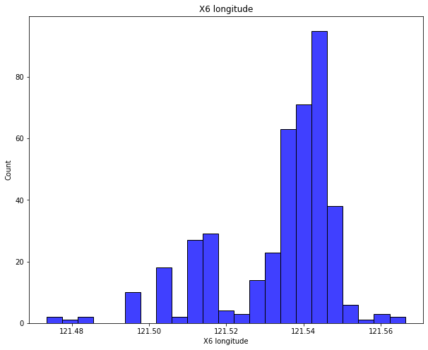

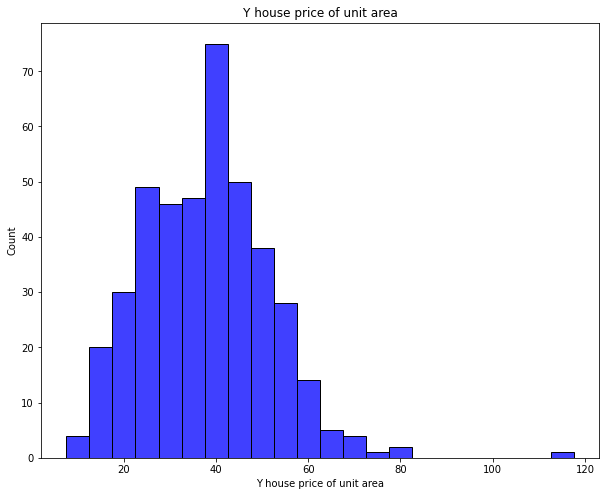

```python
# Distribuciones de las features
for feature in X.columns:
    distribution_chart(dataset, feature)

# Distribución del target
distribution_chart(dataset, y.name)
```

A modo resumen se han encontrado las siguientes características:

- La edad de las casa van desde 0 años (nuevas) hasta 43 años.
- La gran mayoría de las casas son muy cercana a MRT station.
- La gran mayoría de las casas tienen una tienda próxima, pero hay alrededor de 67 casas en las que no hay tiendas cercanas (zonas residenciales).
- La latitud de la casas nos indican que la gran mayoría están en la zona central, ya que hay una mayor frecuencia para valores cercanos a la media.
- La longitud nos indica que la mayoría de casas están hacia el este, cuanto mayor sea el valor más hacia el este estamos.
- Respecto al precio de la vivienda por unidad de area, la gran mayoría de casas rondan entre los 200000\$/Ping hasta los 550000$/Ping, es decir, la gran mayoría de las casas son de clase media haciendo que la clase alta apenas exista.

### 2.2. Preprocesamiento de los datos

Una vez hecho un primer análisis, se trata de "limpiar" el dataset (las features) y adaptarlo a nuestras necesidades (en este caso, predecir el precio de una vivienda).

**Implementación:** comprueba si hay valores nulos. En caso de haberlos, elimina las filas correspondientes.

```python
X.info()
```

```
<class 'pandas.core.frame.DataFrame'>
RangeIndex: 414 entries, 0 to 413
Data columns (total 5 columns):
 #   Column                                  Non-Null Count  Dtype
---  ------                                  --------------  -----
 0   X2 house age                            414 non-null    float64
 1   X3 distance to the nearest MRT station  414 non-null    float64
 2   X4 number of convenience stores         414 non-null    int64
 3   X5 latitude                             414 non-null    float64
 4   X6 longitude                            414 non-null    float64
dtypes: float64(4), int64(1)
memory usage: 16.3 KB
```

Como podemos apreciar no hay valores nulos, por lo que no se elimina ningún registro.

El siguiente paso sería estudiar la correlación entre todas las variables descriptivas (features) numéricas. Esto se hace para asegurarse de que no hay dos variables muy relacionadas entre sí, ya que en tal caso sería conveniente seleccionar una de las dos o combinarlas en una nueva para reducir dimensionalidad.

**Implementación:** muestra la correlación entre todas las features numéricas. Si hay dos con una correlación superior al 90%, elimina una de ellas. Puedes utilizar heatmap, de seaborn, para verlas en un mapa de colores.

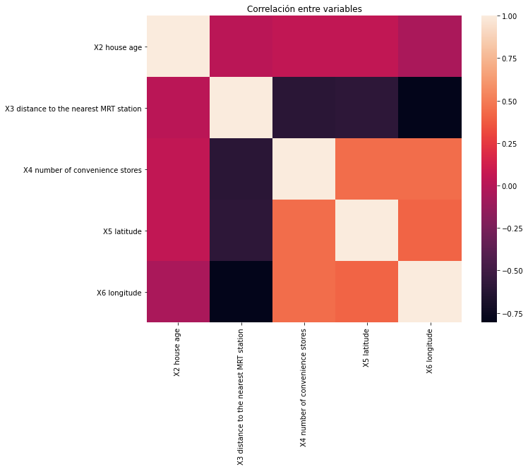

```python
df_corr = X.corr()
fig, ax = plt.subplots(figsize=(10,8))
sns.heatmap(df_corr)
plt.title("Correlación entre variables")
plt.show()
```

Ya tenemos las variables finales con las que trabajaremos. Vamos a observar ahora cuál es la relación de cada una de ellas con el target.

**Implementación:** realiza varios scatterplots cruzando los diferentes atributos descriptivos con la variable target. Se ha de realizar un scatterplot por atributo.

```python
def scatterplot_chart(df, x, y):
    fig, ax = plt.subplots(figsize=(10, 8))
    sns.scatterplot(
        data=df,
        x=df[x],
        y=df[y],
        alpha=.5
    )
    title = "Relación entre " + x + " y " + y
    plt.title(title)
    plt.show()
```

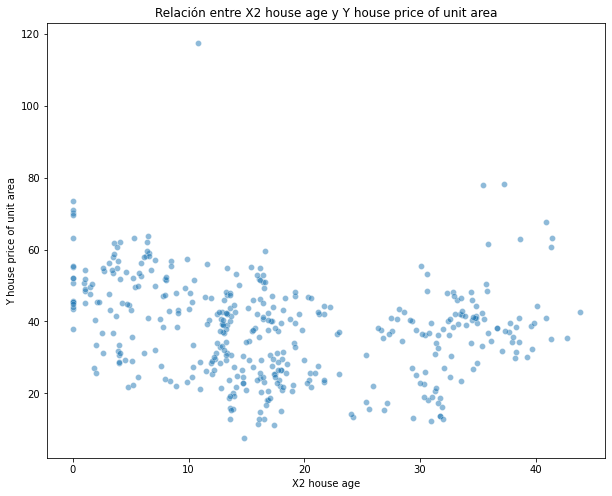

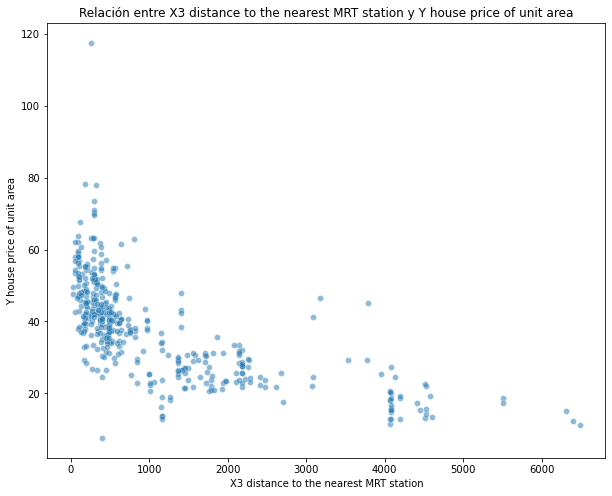

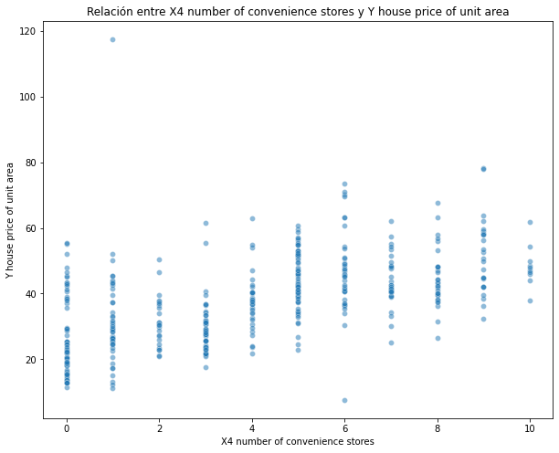

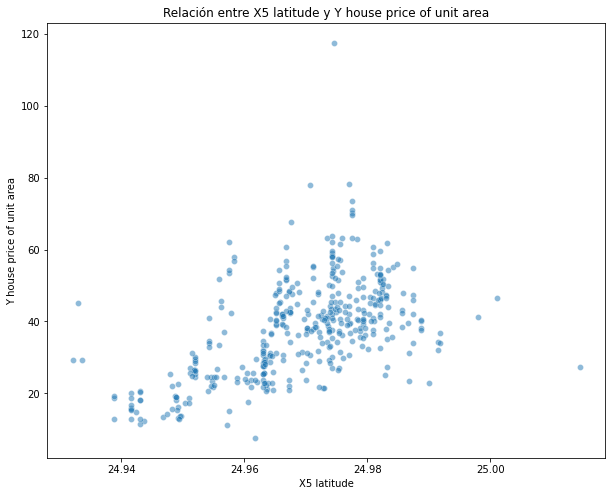

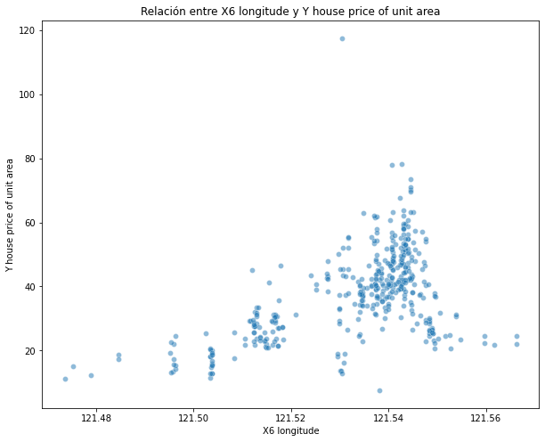

```python
# Relación de las feature con target
for feature in X.columns:
    scatterplot_chart(dataset, feature, y.name)
```

**Análisis:** ¿qué atributos tienen correlación positiva? ¿Cuáles negativa? ¿Cuáles no tienen ninguna correlación? Analiza cada uno de los gráficos. ¿Tiene sentido que la relación de cada atributo con el target sea la encontrada?

De los gráficos anteriores vemos que no hay ninguna correlación superior al 90% en valor absoluto, por lo que no se han eliminado variables del dataset. También cabe destacar que no había registros con valores nulos, por lo que tampoco se han eliminado los mismos.

Respecto a los atributos que tienen correlación positiva son:

- X4 (number of convenience stores) con X5 (latitude) y X6 (longitude).
- X5 (latitude) con X6 (longitude).

De las correlaciones positivas podemos extraer la información de que cuanto más al este y norte estemos más tiendas hay, y cuando más al oeste y al sur menos. Por lo que, las zonas residenciales se encuentras en el suroeste ya que es aquí donde menos tiendas hay, como hemo visto en el apartado anterior.

Respecto a las correlaciones negativas:

- X3 (distance to the nearest MRT station) presenta correlaciones negativas frente a la X4 (number of convenience stores), X5 (latitude) y X6 (longitude).

De dichas correlaciones negativas podemos ver que a medida que aumenta la latitud y la longitud, es decir, más al noreste estamos menos distancia hay a la estación MRT y por lo tanto más tiendas también. Sin embargo, al aumentar la distancia a la estación MRT más al suroeste nos encontramos, habiendo por lo tanto menos tiendas (zonas más residenciales).

El resto de variables no presentan una correlación significativa, ya sea tanto positiva como negativa, es decir, el atributo X2 (house age) no presenta ninguna correlación significativa con ninguna variable.

Por otro lado, vamos a analizar el cómo se relaciona cada variable con el target, es decir, los atributos mencionados anteriormente con el precio de la vivienda.

En cuanto a X2 (house age) y el precio vemos que no hay una relación, es verdad que para viviendas con una edad inferior a 20 años el precio de la vivienda tienda a disminuir, pero pasada estas barrera de los 20 años vuelve a aumentar. Por lo tanto, no podemos decir que hay una relación entre la antigúedad de la vivienda y su precio.

Respecto a X3 (distance to the nearest MRT station) y el precio de la vivienda vemos que sí que hay una relación, a medida que aumenta la distancia disminuye el precio de la misma. Esto tiene sentido, ya que las viviendas más cercanas a estaciones/tiendas suelen estar en zonas más turísticas.

Respecto a X4 (number of convenience stores) y el precio de la vivienda vemos que también hay una ligera relación, a medida que aumenta el número de tiendas tiende a aumentar el precio de la vivienda, es decir, son zonas más pobladas, más turísticas y el precio aumenta.

En cuanto a X5 (latitude), podemos ver que las casas que se encuentran en una zona más céntrica, es decir, ni muy al norte ni muy al sur, suelen ser viviendas más caras y además es una zona donde se encuentran la gran mayoría de las casas.

Finalmente, X6 (longitude) afecta al precio de la vivienda, cuanto más al este las viviendas tienden a ser más caras. Esto tiene todo el sentido, ya que hay más tiendas, menos distancia a la estación MRT...

### 2.3. Entrenamiento de un modelo

Ahora que ya tenemos el dataset limpio y hemos hecho un análisis de las diferentes variables, podemos proceder a entrenar un modelo para predecir el precio de una vivienda. Probaremos con 2 modelos diferentes e interpretaremos sus resultados. Para comenzar, separemos el dataset en train y test.

**Implementación:** divide el *dataset* en dos subconjuntos, *train* (80% de los datos) y *test* (20% restante). Nombraremos los conjuntos: X_train, X_test, y_train e y_test. Utilizaremos la opción random_state=24. Puedes servirte de la implementación *train_test_split* de *sklearn*.

```python
X_train, X_test, y_train, y_test = train_test_split(X, y, test_size=.2, random_state=24)
```

**Implementación:** utiliza un árbol de decisión simple con max_depth=5 para modelar el dataset sobre el conjunto de train. Dibuja el árbol de decisión. Si te queda muy grande, dibuja un árbol entrenado con menor profundidad para que puedas apreciarlo mejor. Utiliza alguna medida de error (puedes escoger la que quieras: MAE, RMSE, ...) para estimar cómo de bien lo ha hecho el modelo prediciedo en train y en test. También servirá para poder comparar a posteriori con otro modelo. Para dibujar el árbol puedes guiarte con este enlace: https://towardsdatascience.com/visualizing-decision-trees-with-python-scikit-learn-graphviz-matplotlib-1c50b4aa68dc. Towardsdatascience es un blog que te deja leer unos cuantos artículos gratuitamente y despues te pide subscripción. Si fuera el caso y ya hubieras llegado al límite, puedes abrir el enlace en una pestaña de navegación privada.

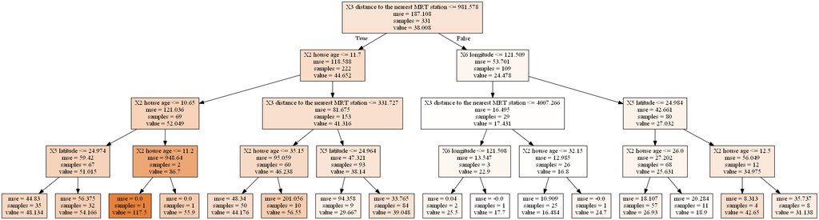

```python
# Creación del modelo
modelo_dtr = DecisionTreeRegressor(max_depth=4, random_state=24)

# Ajuste del modelo
modelo_dtr = modelo_dtr.fit(X_train, y_train)

# Árbol generado
export_graphviz(
    modelo_dtr,
    out_file="tree_dtr.dot",
    feature_names=X.columns,
    filled=True
)

Image(filename='tree_dtr.png')
```

```python
# Importancia de cada variable
print("Importancia de cada variable sobre el 100%:\n")
for name, value in zip(X.columns, modelo_dtr.feature_importances_):
    print(name + " -> " + str(round(value*100, 2)) + " %")
```

```
Importancia de cada variable sobre el 100%:

X2 house age -> 24.98 %
X3 distance to the nearest MRT station -> 66.35 %
X4 number of convenience stores -> 0.0 %
X5 latitude -> 4.56 %
X6 longitude -> 4.12 %
```

```python
# Error cuadrático medio en el entrenamiento
mse_train = round(mean_squared_error(y_train, modelo_dtr.predict(X_train)), 2)

# Error cuadrático medio en la predicción
mse_test = round(mean_squared_error(y_test, modelo_dtr.predict(X_test)), 2)

print("El MSE en el entrenamiento: " + str(mse_train))
print("El MSE en el test: " + str(mse_test))
```

```
El MSE en el entrenamiento: 40.28
El MSE en el test: 43.25
```

**Análisis:** interpreta el árbol de decisión, ¿qué variables son las que han tenido más peso? ¿Has obtenido una buena precisión evaluando en test? ¿Se ha producido overfitting?

A partir del anterior árbol podemos extraer qué variables son las que han tenido más peso, para ello comenzamos por el nodo raíz y vemos cual es el atributo por el que ha separado el árbol, ya que éste será el que más relevancia tiene en el modelo, el atributo en cuestión es X3 (distance to the nearest MRT station).

El segundo atributo más relevante es X2 (house age), ya que éste es el atributo por el cual se divide de nuevo el árbol a partir de los hijos del nodo raíz.

Finalmente, los atributos X5 (latitude) y X6 (longitude) son posteriormente los más relevantes (después de X3 y X2). Cabe destacar que según este modelo, con una profundidad de 4, el atributo X4 (number of convenience stores) no tiene relevancia.

Toda la información comentada anteriormente se puede analizar a partir del gráfico o visualizando la ejecución de "Importancia de cada variable sobre el 100%".

La elección de una profunidad de 4 viene determinada para que el árbol fuera legible, para ello se tiene que hacer click derecho sobre la imagen y seleccionar abrir en una pestaña nueva. Si la profundidad es de 4, vamos a tener 2^4 nodos hoja, es decir, 16 "grupos" por los que el modelo va a clasificar los datos nuevos, en otras palabras, cuando se vaya a predecir los nuevos datos se va a buscar según la relevancia de los atributos comentados qué nodo hoja le correspondería a dicha observación, dando lugar a el valor predicho.

Por ejemplo, si estamos ante una nueva observación en la que se caracteriza por:

- Tiene un X3 (distance to the nearest MRT station) <= 981.578.
- Tiene un X2 (house age) <= 11.7 y X2 <= 10.65.
- Tiene un X5 (latitude) <= 24.974.

Entonces el valor predicho que nos vas a devolver el modelo va a ser igual a 48.134.

Por otro lado, se ha calculado tanto el error de entramiento como el de test, en ambos es a partir del MSE, es decir, del error cuadrático medio, éste es el promedio de los errores elevados al cuadrado, donde los errores se calculan como la diferencia entre el valor real y el estimado.

En el entrenamiento el MSE es igual a 40.28 y en el test es igual a 43.25, como podemos observar ambos errores son muy similares, esto nos da una idea de que el modelo está en unas condiciones óptimas, es decir, no se produce underfitting (el MSE del entrenamiento tendría que ser mucho más elevado y el MSE de test no variaría mucho, dependiendo de como sea el error de entramiento) y tampoco se produce overfitting (el MSE de entrenamiento sería muy bajo pero el de test sería muy elevado).

En resumen, este modelo sí que comete cierto error ya que su MSE es 40 aproximadamente tanto para el entrenamiento como para el test, pero tenemos un modelo ni muy general ni muy sobreajustado.

**Implementación:** utiliza Random Forest o Gradient Boosting para modelar el dataset. Esta vez vamos a optimizar el modelo para obtener los mejores resultados posibles. Tal y como hemos visto anteriormente, recuerda seguir los siguientes pasos: - Utilizar el dataset de train para encontrar los mejores hiperparámetros haciendo cross-validation. - Entrenar el modelo con train, predecir con train y test y calcular el error (MAE, RMSE, ...)

```python
# Búsqueda de los mejores hiperparámetros
# Definimos los parámetros para GridSearchCV
parametros = {
    'learning_rate': [0.01, 0.1, 1, 2],
    'n_estimators': [x for x in range(40,61)]
}

# Definimos el modelo de GridSearchCV
modelo_GridSearchCSV = GridSearchCV(
    GradientBoostingRegressor(random_state=24),
    param_grid=parametros,
    cv=4
)

# Ajustamos el modelo
modelo_GridSearchCSV = modelo_GridSearchCSV.fit(X_train, y_train)

# Hiperparámetros
print("El mejor learning_rate es: ", modelo_GridSearchCSV.best_params_["learning_rate"])
print("El mejor n_estimators es: ", modelo_GridSearchCSV.best_params_["n_estimators"])
```

```
El mejor learning_rate es:  0.1
El mejor n_estimators es:  43
```

```python
# Creación del modelo optimizado
modelo_gbr = GradientBoostingRegressor(
    learning_rate=0.1,
    n_estimators=43,
    random_state=24
)

# Ajustamos el modelo optimizado
modelo_gbr = modelo_gbr.fit(X_train, y_train)

# Error cuadrático medio en el entrenamiento
mse_train = round(mean_squared_error(y_train, modelo_gbr.predict(X_train)), 2)

# Error cuadrático medio en la predicción
mse_test = round(mean_squared_error(y_test, modelo_gbr.predict(X_test)), 2)

print("El MSE en el entrenamiento: " + str(mse_train))
print("El MSE en el test: " + str(mse_test))
```

```
El MSE en el entrenamiento: 22.92
El MSE en el test: 33.73
```

Un Random Forest / Gradient Boosting no es tan fácil de interpretar como un simple Decision Tree. No podemos dibujar un árbol porque son combinaciones de muchos árboles, pero sí que podemos saber cuáles han sido las variables más decisivas a la hora de generar el modelo. Para saberlo, no podremos hacerlo mirando cómo se divide el árbol, sino que se lo tendremos que consultar al modelo através de la "feature importance" de éste.

**Implementación:** muestra cada variable del modelo aprendido junto con su feature importance.

```python
# Importancia de cada variable
print("Importancia de cada variable sobre el 100%:\n")
for name, value in zip(X.columns, modelo_gbr.feature_importances_):
    print(name + " -> " + str(round(value*100, 2)) + " %")
```

```
Importancia de cada variable sobre el 100%:

X2 house age -> 22.2 %
X3 distance to the nearest MRT station -> 61.67 %
X4 number of convenience stores -> 0.92 %
X5 latitude -> 11.5 %
X6 longitude -> 3.72 %
```

**Análisis:** interpreta el clasificador, ¿cuáles son las variables que han tenido más peso? ¿Has obtenido una buena precisión evaluando en test? ¿Se ha producido overfitting?

En este caso, el modelo ha seguido teniendo en cuenta el mismo orden respecto al peso de atributos, es decir, los atributos más relevantes son:

- 1º: X3 (distance to the nearest MRT station).
- 2º: X2 (house age).
- 3º: X5 (latitude).
- 4º: X6 (longitude).
- 5º: X4 (number of convenience stores).

Cabe destacar que en este caso aunque sea por poco, la variable X4 sí que participa en el modelo, algo que no sucedía en el modelo anterior. Viendo la clasificación, vemos que los atributos más significativos para dictaminar el precio de una vivienda son tanto X3 y X2, es decir, tanto la distancia a la estación MRT como la antigüedad de la casa. También llama la atención que es más importante si una vivienda está situada en el norte/centro/sur de la ciudad que si se encuentra en el oeste/este.

Respecto a cómo ajusta el modelo, vemos que al buscar los parámetros óptimos para este problema se ha reducido tanto el error de entrenamiento como el de test. Ahora el MSE de entrenamiento es 22.92 y el MSE de test es 33.73, el primero se ha reducido casi a la mitad mientras que el segundo se ha reducido en 10 puntos. Por lo tanto, vemos que esta búsqueda exhaustiva de los hiperparámetros nos ha permitido obtener un mejor modelo a la hora de predecir valores a partir de nuevas observaciones.

En cuanto a si hay underfitting u overfitting, vemos que no, en el primer caso el modelo consigue ajustar mejor los datos gracias a una mejora en la optimización de los hiperparámetros pero el error de entramiento se mantiene bajo, es decir, no sobregeneraliza demasiado. Respecto a si hay overfitting, es verdad que el modelo ajusta mejor los datos y reduce el error de entrenamiento, pero vemos que el error de test sigue siendo bajo, es decir, el modelo ha sido capaz de ajustar mejor los datos y consigue generalizar de forma idónea manteniendo un error de test más bajo que en el modelo anterior.

En resumen, el modelo generado en este apartado se comporta mejor que el modelo anterior al reducir el MSE tanto de entrenamiento como de test.

### 2.4. Predicción de casos nuevos

Hasta ahora hemos entrenado un modelo y hemos evaluado en test para hacernos una idea de la precisión de nuestro modelo con datos reales. Ahora vamos a utilizarlo.

**Implementación:** - Caso 1: queremos comprar una vivienda que está situada a 1km de la estación de tren, concretamente sus coordenadas son: 24.87745, 121.31683. La vivienda tiene 3 tiendas cerca y se construyó hace 15 años. Se vende por 24500€/m2 y queremos saber si está por encima o por debajo del precio de mercado. - Caso 2: somos una empresa que se dedica a hacer negocio comprando pisos baratos, arreglándolos y volviéndolos a vender más caros. Queremos saber qué viviendas del conjunto de datos se venden por debajo de su precio de mercado ("chollos") para poder comprarlas y revenderlas en un futuro.

```python
# Caso 1
pred1 = round(modelo_gbr.predict([[15, 1000, 3, 24.87745, 121.31683]])[0] * 1000, 2)
print("El precio de mercado es: " + str(pred1) + " €/m2")
```

```
El precio de mercado es: 30244.82 €/m2
```

El precio de mercado es de 30244.82 €/m2, la están vendiendo por 24500 €/m2, por lo que comprar esta vivienda estaría bien ya que la están vendiendo por un valor menor que el precio de mercado.

```python
# Caso 2
dataset["price_predict"] = modelo_gbr.predict(X)
dataset[dataset["Y house price of unit area"] < dataset["price_predict"]]
```

|  | No | X1 transaction date | X2 house age | X3 distance to the nearest MRT station | X4 number of convenience stores | X5 latitude | X6 longitude | Y house price of unit area | price_predict |
| --- | --- | --- | --- | --- | --- | --- | --- | --- | --- |
| 0 | 1 | 2012.916667 | 32.0 | 84.87882 | 10 | 24.98298 | 121.54024 | 37.9 | 47.810318 |
| 1 | 2 | 2012.916667 | 19.5 | 306.59470 | 9 | 24.98034 | 121.53951 | 42.2 | 46.620277 |
| 4 | 5 | 2012.833333 | 5.0 | 390.56840 | 5 | 24.97937 | 121.54245 | 43.1 | 48.429926 |
| 7 | 8 | 2013.416667 | 20.3 | 287.60250 | 6 | 24.98042 | 121.54228 | 46.7 | 46.754242 |
| 9 | 10 | 2013.416667 | 17.9 | 1783.18000 | 3 | 24.96731 | 121.51486 | 22.1 | 24.824088 |
| ... | ... | ... | ... | ... | ... | ... | ... | ... | ... |
| 405 | 406 | 2012.666667 | 23.0 | 130.99450 | 6 | 24.95663 | 121.53765 | 37.2 | 38.668629 |
| 406 | 407 | 2013.166667 | 1.9 | 372.13860 | 7 | 24.97293 | 121.54026 | 40.5 | 45.573156 |
| 407 | 408 | 2013.000000 | 5.2 | 2408.99300 | 0 | 24.95505 | 121.55964 | 22.3 | 26.509987 |
| 409 | 410 | 2013.000000 | 13.7 | 4082.01500 | 0 | 24.94155 | 121.50381 | 15.4 | 17.900165 |
| 410 | 411 | 2012.666667 | 5.6 | 90.45606 | 9 | 24.97433 | 121.54310 | 50.0 | 56.685391 |

216 rows × 9 columns

En este caso hay 216 viviendas cuyo precio por el que se venden es menor que el precio de mercado.